# R_Markdown_Class_Note

Shakiba Kazemian

2025-02-25

## R Markdown for Iterative Programming

R Markdown is a powerful tool for iterating and refining programs, integrating code, output, and documentation in one document. It supports multiple languages, facilitates collaboration, and enables dynamic reports in formats like HTML, PDF, and Word. And it is a great tool for reproduciblity.

### R Markdown and Code Chunck

To include R code in your Rmarkdwon document, you will need to insert a code chunk.

This is an example of R code: “Include” option shows the code chunk “Echo” option shows the output

```
##       mpg             cyl             disp             hp
##  Min.   :10.40   Min.   :4.000   Min.   : 71.1   Min.   : 52.0
##  1st Qu.:15.43   1st Qu.:4.000   1st Qu.:120.8   1st Qu.: 96.5
##  Median :19.20   Median :6.000   Median :196.3   Median :123.0
##  Mean   :20.09   Mean   :6.188   Mean   :230.7   Mean   :146.7
##  3rd Qu.:22.80   3rd Qu.:8.000   3rd Qu.:326.0   3rd Qu.:180.0
##  Max.   :33.90   Max.   :8.000   Max.   :472.0   Max.   :335.0
##       drat             wt             qsec             vs
##  Min.   :2.760   Min.   :1.513   Min.   :14.50   Min.   :0.0000
##  1st Qu.:3.080   1st Qu.:2.581   1st Qu.:16.89   1st Qu.:0.0000
##  Median :3.695   Median :3.325   Median :17.71   Median :0.0000
##  Mean   :3.597   Mean   :3.217   Mean   :17.85   Mean   :0.4375
##  3rd Qu.:3.920   3rd Qu.:3.610   3rd Qu.:18.90   3rd Qu.:1.0000
##  Max.   :4.930   Max.   :5.424   Max.   :22.90   Max.   :1.0000
##        am              gear            carb
##  Min.   :0.0000   Min.   :3.000   Min.   :1.000
##  1st Qu.:0.0000   1st Qu.:3.000   1st Qu.:2.000
##  Median :0.0000   Median :4.000   Median :2.000
##  Mean   :0.4062   Mean   :3.688   Mean   :2.812
##  3rd Qu.:1.0000   3rd Qu.:4.000   3rd Qu.:4.000
##  Max.   :1.0000   Max.   :5.000   Max.   :8.000
```

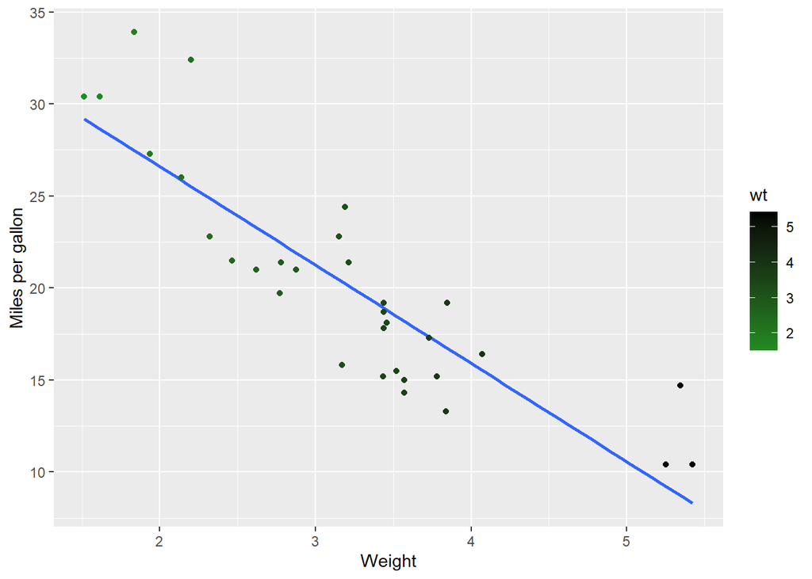

```r
data("mtcars")
ggplot(mtcars, aes(x = wt, y = mpg)) +
  geom_smooth(method = lm, se = FALSE) +
  geom_point(aes(color = wt)) +
  xlab("Weight") +
  ylab("Miles per gallon") +
  scale_colour_gradient(low = "forestgreen", high = "black")
```

You can also R Markdown Formatting Options to organize your documents:

### Headers:

# First level header

## secod level header

### Italics (by putting the sentence between `* *`):

`*This text is in italics*`

### Bold (by putting the sentence between `** **` or `__ __`):

`**This text is in bold**` `__This text is also in bold__`

### List of items (by putting the - or numbers on the left side of the items name):

- Item one
- Item two
- Subitem two
1. the first item
2. the second item
3. the third item
   - one unordered item
   - one unordered item

### Links (by putting the [ ] on both sides of the sentence):

[Link to my github](https://github.com/szk0263/PLPA6820_SK)

### Images (by putting the ![ ] on both sides of the image name following by the image path in paranthesis):

[figure not shown]

Shrek ggplot

If you forgot the exclamation mark (!), it will become just a link

### Formatted tables:

```r
kable(head(mtcars, n = 5), digits = 3, format = "markdown")
```

|  | mpg | cyl | disp | hp | drat | wt | qsec | vs | am | gear | carb |
| --- | --- | --- | --- | --- | --- | --- | --- | --- | --- | --- | --- |
| Mazda RX4 | 21.0 | 6 | 160 | 110 | 3.90 | 2.620 | 16.46 | 0 | 1 | 4 | 4 |
| Mazda RX4 Wag | 21.0 | 6 | 160 | 110 | 3.90 | 2.875 | 17.02 | 0 | 1 | 4 | 4 |
| Datsun 710 | 22.8 | 4 | 108 | 93 | 3.85 | 2.320 | 18.61 | 1 | 1 | 4 | 1 |
| Hornet 4 Drive | 21.4 | 6 | 258 | 110 | 3.08 | 3.215 | 19.44 | 1 | 0 | 3 | 1 |
| Hornet Sportabout | 18.7 | 8 | 360 | 175 | 3.15 | 3.440 | 17.02 | 0 | 0 | 3 | 2 |

## Organizing a repository and editing a readme using Markdown

### Directory Tree

We can also create a file tree using the fs package in R. This package allows us to print the directory structure, which is useful for providing explicit instructions in the README about each file’s purpose. We can copy the file tree text and paste it into a markdown block to make it viewable on GitHub. Labeling the file tree and providing descriptions for each file helps users understand the project structure.

First install the package “fs” Then run this code:

```r
fs::dir_tree()
```

```
## .
## ├── R_Markdown_Class_Note.html
## ├── R_Markdown_Class_Note.Rmd
## ├── R_Markdown_Class_Note_files
## │   └── figure-html
## │       └── Include figures-1.png
## └── Shrek.jpg
```

### Zenodo Link

Zenodo allows us to create a DOI (Digital Object Identifier) for our repository, making it citable. By linking your Zenodo account to GitHub, you can generate a Zenodo badge that provides a direct link to your release. This badge can be added to your README for easy access.

To create a Zenodo badge for your release:

1. **Ensure your GitHub account is linked to Zenodo.**
2. **Create a release on GitHub**, which Zenodo will recognize and assign a DOI.
3. **Include the badge in your README** to provide a direct citation link.

### Steps to Create a GitHub Release

- **Release Title:** Enter a meaningful title for your release.
- **Description:** Provide details about the release. You can mention contributors using `@username`, which will include their avatars in the Contributors section. You can also generate release notes automatically by clicking **Generate release notes**.
- **Binary Files:** If applicable, upload compiled programs or other binary files by dragging and dropping them into the binaries section.
- **Pre-release Option:** Mark the release as a **pre-release** if it is not production-ready.
- **Set as Latest Release:** If unchecked, GitHub will assign the latest release based on semantic versioning.
- **GitHub Discussions (Optional):** If enabled, you can create a discussion for the release.
  - Click **Create a discussion for this release**.
  - Select a category from the dropdown menu.

### Publishing Your Release

- Click **Publish release** to make it public.
- Click **Save draft** to work on it later.

You can view both published and draft releases in your repository’s **Releases** section.